```python
import numpy as np, pandas as pd
from IPython.display import display, Image, Latex, HTML
import statsmodels.api as sm; from statsmodels.iolib.summary2 import summary_col
import imageio, os

import informationalTable
import countryLevelGraphs
import cantonLevelGraphs
import residGraph
```

# Welcome!

## Created 4-24-2022 by Lucas Voichick

#### The following code shows the data processing pipeline that I created for my Honors Thesis.

#### You can [click here](https://urldefense.com/v3/__https://luvoichickgithub.github.io/HonorsThesis.LuVoichick.pdf__;!!PbcgRCL8dg!JnWxHnB8w5Y4sfeWASzE5bR7Eal-xtvbExRwdGD2S-GA8vlWaSqBVn0M39wxXOClPxht2tuZeoz9qrXP_KRYA48$) to read my thesis

.

### Next line runs only if data has not yet been concatted. Gzip version is imported in next cell

```python
# Imports and concats all NEUZU data

if os.path.exists('NewRegistrationData.gz') == False: # If pre-concatted data is available, concat and gzip to a single dataframe
    assert False, "Wait! Comment this out only if you have the original paid data that includes PLZ information along with computer memory and time to spare. Otherwise just import the zipped csv file on the next line"
    Dataframe_data2016 = pd.read_excel('data/NEUZU-2016.xlsx', engine='openpyxl')
    Dataframe_data2017 = pd.read_excel('data/NEUZU-2017.xlsx', engine='openpyxl')
    Dataframe_data2018 = pd.read_excel('data/NEUZU-2018.xlsx', engine='openpyxl')
    Dataframe_data2019 = pd.read_excel('data/NEUZU-2019.xlsx', engine='openpyxl')
    Dataframe_data2020 = pd.read_excel('data/NEUZU-2020 delfirstline.xlsx', engine='openpyxl')
    Dataframe_data2021 = pd.read_excel('data/NEUZU-2021 delfirstline.xlsx', engine='openpyxl')

    #combining all data into a dataframe and saving as a .csv file and gzipped .csv file
    allNEUZU_together = pd.concat([Dataframe_data2016,Dataframe_data2017,Dataframe_data2018, Dataframe_data2019,Dataframe_data2020,Dataframe_data2021])
    allNEUZU_together = allNEUZU_together.drop(columns=['PLZ'])
    allNEUZU_together.to_csv('NewRegistrationData.gz', compression='gzip')
```

## Import all data

```python
allNEUZU_together = pd.read_csv('NewRegistrationData.gz', low_memory = False)
print("Imported entire NEUZU dataset, len:", "{:,}".format(len(allNEUZU_together)))
```

```
Imported entire NEUZU dataset, len: 2,425,320
```

## Filtering, Aggregating at Quarter Level, Classifying by Electric / Non-Electric

```python
### # # # # # # # # # # # # # # # # ##
## Filtering Unwanted Registrations ##
### # # # # # # # # # # # # # # # # ##

## removing car class =! 1, 2, 10 to keep only personal vehicles ##
carClassFilter = allNEUZU_together['Fahrzeugart_Code'].isin([1,2,10])
filteredNEUZU = allNEUZU_together[carClassFilter]

## removing some anomalies with unexpected number of seats ##
filteredNEUZU = filteredNEUZU[~((filteredNEUZU['SitzplÃ¤tze'] <= 1.0) | (filteredNEUZU['SitzplÃ¤tze'] > 39.0))]

## removing those registered in unknown cantons ##
filteredNEUZU = filteredNEUZU[filteredNEUZU['Staat'] == 'Schweiz']

## removing registrations with missing datapoints ##
filteredNEUZU = filteredNEUZU.dropna(subset=['Erstinverkehrsetzung_Monat','Inverkehrsetzung_Kanton','Erstinverkehrsetzung_Jahr','Treibstoff', 'Treibstoff_Code'])

## removing datapoints with mislabelled canton registration ##
cantons_abbr = ['AG', 'AR', 'AI', 'BL', 'BS', 'BE', 'FR', 'GE', 'GL', 'GR', 'JU', 'LU', 'NE', 'NW', 'OW', 'SH', 'SZ', 'SO', 'SG', 'TG', 'TI', 'UR', 'VS', 'VD', 'ZG', 'ZH']
filteredNEUZU = filteredNEUZU[filteredNEUZU['Inverkehrsetzung_Kanton'].isin(cantons_abbr)]
print("Removed", "{:,}".format(len(allNEUZU_together) - len(filteredNEUZU)), "unwanted data points.", "{:,}".format(len(filteredNEUZU)), "remain")
```

```
Removed 692,600 unwanted data points. 1,732,720 remain
```

```python
# Appending a quarter term
monthConditions = [
    (filteredNEUZU['Erstinverkehrsetzung_Monat'] <= 3),
    (filteredNEUZU['Erstinverkehrsetzung_Monat'] >= 4) & (filteredNEUZU['Erstinverkehrsetzung_Monat'] <= 6),
    (filteredNEUZU['Erstinverkehrsetzung_Monat'] >= 7) & (filteredNEUZU['Erstinverkehrsetzung_Monat'] <= 9),
    (filteredNEUZU['Erstinverkehrsetzung_Monat'] >= 10)]

filteredNEUZU['Quarter'] = np.select(monthConditions, [1,2,3,4])
filteredNEUZU['YearQuarter'] = filteredNEUZU['Erstinverkehrsetzung_Jahr'].astype(str)+'-'+filteredNEUZU['Quarter'].astype(str)
filteredNEUZU['YearQuarterCanton'] = filteredNEUZU['YearQuarter'] + '-' + filteredNEUZU['Inverkehrsetzung_Kanton']
```

```python
# Separating by electric and non-electric
electricFilter = (filteredNEUZU['Treibstoff_Code'] == 'E') | (filteredNEUZU['Treibstoff_Code'] == 'X') | ((filteredNEUZU['Treibstoff_Code'] == 'R') & (filteredNEUZU['Hubraum'] == 0))
NEUZU_electric = filteredNEUZU[electricFilter]
NEUZU_nonEV    = filteredNEUZU[~electricFilter]

print("Of the", "{:,}".format(len(NEUZU_nonEV) + len(NEUZU_electric)), "registrations between 2016-2021,","{:,}".format(len(NEUZU_nonEV)),
      "are not fully electric vehicles and", "{:,}".format(len(NEUZU_electric)),"are fully electric")
```

```
Of the 1,732,720 registrations between 2016-2021, 1,654,831 are not fully electric vehicles and 77,889 are fully electric
```

## Organizing data by canton, registration quarter-year, eletric vehicle, EV Ratio

#### Horizontal and Vertical Organization

```python
# Breaks up electric and non-electric registrations by electric vehicle, non electric vehicle,
# all registrations, and EV registration fraction at the canton level and returns them as a dataframe
def EV_NonEv_AllRegistrations_EVFration(canton):

    NotEVsNEUZU_byQuarterCanton = NEUZU_nonEV[NEUZU_nonEV['Inverkehrsetzung_Kanton'].isin(canton)]['YearQuarter'].value_counts(
        ).reindex(NEUZU_nonEV.YearQuarter.unique(), fill_value=0).sort_index(ascending=True).to_frame()

    EVsNEUZU_byQuarterCanton = NEUZU_electric[NEUZU_electric['Inverkehrsetzung_Kanton'].isin(canton)]['YearQuarter'].value_counts(
        ).reindex(NEUZU_electric.YearQuarter.unique(), fill_value=0).sort_index(ascending=True).to_frame()

    ## If all cantons are passed through as an arg, set name to 'All'
    canton = len(canton) > 1 and '_All' or "_"+ str(canton).replace("[","").replace("]","").replace("'","")

    YQRegistrations = pd.concat([EVsNEUZU_byQuarterCanton,NotEVsNEUZU_byQuarterCanton], axis = 1)
    YQRegistrations.columns = ['EVs' + canton, 'NonEVs' + canton]

    #calculating total number of vehicles, electric vehicle ratio
    YQRegistrations['AllVehicles'+canton] = YQRegistrations['EVs' + canton] + YQRegistrations['NonEVs'+canton]
    YQRegistrations['EVRatio'+canton] = (YQRegistrations['EVs' + canton] / ( YQRegistrations['AllVehicles'+canton] ) *100).round(4)
    return YQRegistrations
```

### Horizontal Organization

```python
#Calculates EV, nonEV, all, and Ratio for each canton, individually

YQRegistrations = pd.DataFrame([])
for canton in cantons_abbr:
    YQRegistrations = pd.concat([YQRegistrations,EV_NonEv_AllRegistrations_EVFration([canton])], axis = 1)

#calculates EV, nonEV, all, and Ratio for all cantons together
YQRegistrations = pd.concat([YQRegistrations,EV_NonEv_AllRegistrations_EVFration(cantons_abbr)], axis = 1).reset_index().rename(columns={"index": "YearQuarter"})

YQRegistrations.to_csv("EVData_HorizontallyOrganized.csv")
```

## Horizontally organized df has all four Data Terms for each canton across all quarters

#### Sampled selection of row and columns shown below:

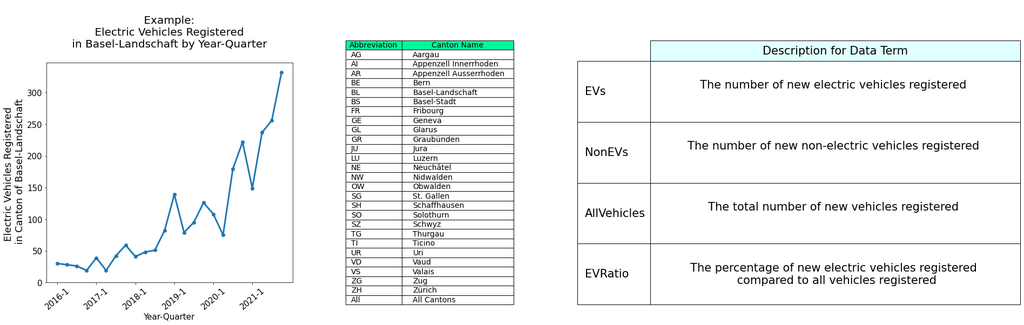

|  | EVs_TI | NonEVs_TI | AllVehicles_TI | EVRatio_TI | EVs_UR | NonEVs_UR | AllVehicles_UR | EVRatio_UR | EVs_VS | NonEVs_VS | AllVehicles_VS | EVRatio_VS | EVs_VD | NonEVs_VD | AllVehicles_VD | EVRatio_VD | EVs_ZG | NonEVs_ZG | AllVehicles_ZG | EVRatio_ZG | EVs_ZH | NonEVs_ZH | AllVehicles_ZH | EVRatio_ZH | EVs_All | NonEVs_All | AllVehicles_All | EVRatio_All |
| --- | --- | --- | --- | --- | --- | --- | --- | --- | --- | --- | --- | --- | --- | --- | --- | --- | --- | --- | --- | --- | --- | --- | --- | --- | --- | --- | --- | --- |
| 1 | 29 | 5030 | 5059 | 0.5732 | 1 | 321 | 322 | 0.3106 | 26 | 3661 | 3687 | 0.7052 | 59 | 8940 | 8999 | 0.6556 | 24 | 1697 | 1721 | 1.3945 | 216 | 13525 | 13741 | 1.5719 | 803 | 85761 | 86564 | 0.9276 |
| 3 | 33 | 5582 | 5615 | 0.5877 | 1 | 373 | 374 | 0.2674 | 26 | 3730 | 3756 | 0.6922 | 63 | 9269 | 9332 | 0.6751 | 27 | 1539 | 1566 | 1.7241 | 221 | 13150 | 13371 | 1.6528 | 955 | 83733 | 84688 | 1.1277 |
| 5 | 42 | 5207 | 5249 | 0.8002 | 4 | 380 | 384 | 1.0417 | 36 | 3555 | 3591 | 1.0025 | 92 | 9148 | 9240 | 0.9957 | 36 | 1862 | 1898 | 1.8967 | 210 | 13842 | 14052 | 1.4944 | 1008 | 85986 | 86994 | 1.1587 |
| 7 | 54 | 5414 | 5468 | 0.9876 | 4 | 302 | 306 | 1.3072 | 63 | 3526 | 3589 | 1.7554 | 113 | 9000 | 9113 | 1.2400 | 35 | 1744 | 1779 | 1.9674 | 505 | 13050 | 13555 | 3.7256 | 1627 | 80620 | 82247 | 1.9782 |
| 9 | 41 | 4917 | 4958 | 0.8269 | 1 | 341 | 342 | 0.2924 | 33 | 3173 | 3206 | 1.0293 | 95 | 8683 | 8778 | 1.0823 | 32 | 1741 | 1773 | 1.8049 | 288 | 13205 | 13493 | 2.1344 | 1165 | 85198 | 86363 | 1.3490 |
| 11 | 55 | 4621 | 4676 | 1.1762 | 1 | 222 | 223 | 0.4484 | 43 | 2527 | 2570 | 1.6732 | 90 | 7828 | 7918 | 1.1367 | 47 | 1478 | 1525 | 3.0820 | 433 | 11772 | 12205 | 3.5477 | 1700 | 72263 | 73963 | 2.2984 |
| 13 | 89 | 4834 | 4923 | 1.8078 | 4 | 314 | 318 | 1.2579 | 95 | 3137 | 3232 | 2.9394 | 319 | 8687 | 9006 | 3.5421 | 80 | 1650 | 1730 | 4.6243 | 650 | 12378 | 13028 | 4.9893 | 2870 | 83548 | 86418 | 3.3211 |
| 15 | 187 | 5112 | 5299 | 3.5290 | 8 | 242 | 250 | 3.2000 | 111 | 2991 | 3102 | 3.5783 | 518 | 8497 | 9015 | 5.7460 | 87 | 1559 | 1646 | 5.2855 | 971 | 12941 | 13912 | 6.9796 | 4266 | 80364 | 84630 | 5.0408 |
| 17 | 112 | 2886 | 2998 | 3.7358 | 8 | 199 | 207 | 3.8647 | 70 | 1839 | 1909 | 3.6668 | 312 | 4893 | 5205 | 5.9942 | 56 | 1027 | 1083 | 5.1708 | 556 | 7212 | 7768 | 7.1576 | 2531 | 46655 | 49186 | 5.1458 |
| 19 | 375 | 4407 | 4782 | 7.8419 | 26 | 235 | 261 | 9.9617 | 340 | 2490 | 2830 | 12.0141 | 763 | 6971 | 7734 | 9.8655 | 217 | 1412 | 1629 | 13.3211 | 2075 | 10389 | 12464 | 16.6479 | 8302 | 65458 | 73760 | 11.2554 |
| 21 | 400 | 3697 | 4097 | 9.7632 | 26 | 252 | 278 | 9.3525 | 364 | 2388 | 2752 | 13.2267 | 658 | 6657 | 7315 | 8.9952 | 186 | 1380 | 1566 | 11.8774 | 1383 | 9706 | 11089 | 12.4718 | 7516 | 62515 | 70031 | 10.7324 |
| 23 | 510 | 3046 | 3556 | 14.3420 | 43 | 181 | 224 | 19.1964 | 511 | 1942 | 2453 | 20.8316 | 1188 | 5147 | 6335 | 18.7530 | 283 | 1176 | 1459 | 19.3968 | 2305 | 7272 | 9577 | 24.0681 | 11288 | 47837 | 59125 | 19.0918 |

```python
dataTerm   = 'EVs'#options include EVs, NonEVs, AllVehicles, EVRatio (see table at right)
cantonAbbr = 'BL' # 26 different canton options for graph shown in center table below (see table in center)

informationalTable.HorizontalData_InformationalGraphAndTable(dataTerm, cantonAbbr)
pd.options.display.max_columns = 100
YQRegistrations.iloc[1::2, 81:]
```

## Organizes vertically for regression

```python
Regression_CYQ = pd.DataFrame([])
mergedDf = pd.DataFrame([])

for canton in cantons_abbr:
    CantonVals = EV_NonEv_AllRegistrations_EVFration([canton])
    CantonVals['CantonName'] = canton
    temp = pd.concat([pd.DataFrame([]),CantonVals], axis = 0).reset_index().rename(columns={"index": "YearQuarter", "EVs_" + canton: "EVs","NonEVs_" + canton: "NonEVs","AllVehicles_" + canton: "AllVehicles","EVRatio_" + canton: "EVRatio"})
    Regression_CYQ = pd.concat([Regression_CYQ, temp], ignore_index = True)

Regression_CYQ['CantonYearQuarter'] = Regression_CYQ['CantonName'] + Regression_CYQ['YearQuarter'].astype(str)
Regression_CYQ['CantonYear'] = Regression_CYQ['CantonName'] +"-"+ Regression_CYQ['YearQuarter'].str[0:4]
Regression_CYQ['Year'] =    Regression_CYQ['YearQuarter'].str[0:4].astype(int)
Regression_CYQ['Quarter'] = Regression_CYQ['YearQuarter'].str[5].astype(int)
```

## Appending regressors (purchase premiums, charging subsidies, tax ratio, population density)

```python
# Appending a purchase premium term
purchasePremium = [
    (Regression_CYQ['CantonName'] == 'TG') & (Regression_CYQ['Year'] >= 2021),
    (Regression_CYQ['CantonName'] == 'TG') & (Regression_CYQ['Year'] == 2020),
    (Regression_CYQ['CantonName'] == 'TG') & (Regression_CYQ['Year'] == 2019),

    (Regression_CYQ['CantonName'] == 'TI') & ((Regression_CYQ['Year'] >= 2020) | ((Regression_CYQ['Year'] >= 2019) & (Regression_CYQ['Quarter'] >= 3))),

    (Regression_CYQ['CantonName'] == 'VS') & ((Regression_CYQ['Year'] == 2021) | ((Regression_CYQ['Year'] >= 2020) & (Regression_CYQ['Quarter'] == 4))),

    (Regression_CYQ['CantonName'] == 'SH') & ((Regression_CYQ['Year'] >= 2021))
]

premium_1000 = [2.0,3.5,4.0,  2,   3.5,   2]

Regression_CYQ['PP_1000'] = np.select(purchasePremium, premium_1000)
Regression_CYQ['PP_1000'] = np.where(Regression_CYQ['PP_1000'] > 0, Regression_CYQ['PP_1000'], 0)
```

Info on Purchase Premium Policies:

**Thurgau**  
In 2019, a premium of [4000 CHF](https://urldefense.com/v3/__https://akuratleag.ch/userdata/pdf/foerderprogramm-tg-2019-v1-0.pdf__;!!PbcgRCL8dg!JnWxHnB8w5Y4sfeWASzE5bR7Eal-xtvbExRwdGD2S-GA8vlWaSqBVn0M39wxXOClPxht2tuZeoz9qrXP5Efol1M$) is offered  
In 2020, decrease offer to 3500 CHF  
In 2021, decrease to 2000 CHF

**Ticino**  
Starting July 1, 2019, a premium of [2000 CHF](https://urldefense.com/v3/__https://www4.ti.ch/index.php?id=34457__;!!PbcgRCL8dg!JnWxHnB8w5Y4sfeWASzE5bR7Eal-xtvbExRwdGD2S-GA8vlWaSqBVn0M39wxXOClPxht2tuZeoz9qrXPToo4NIw$) is offered

**Valais**  
From Nov. 1 2020 to end of 2022, a premium of [3500 CHF](https://urldefense.com/v3/__https://auto-hermann.ch/elektro-competence/foerderbeitraege/__;!!PbcgRCL8dg!JnWxHnB8w5Y4sfeWASzE5bR7Eal-xtvbExRwdGD2S-GA8vlWaSqBVn0M39wxXOClPxht2tuZeoz9qrXPYOnaNCA$) is offered

**Schaffhausen**  
Starting in Jan 2021, a premium of 2000 CHF is offered

```python
# Appending a charging station subsidy term
csSubsidy = [
    (Regression_CYQ['CantonName'] == 'GE') &  (Regression_CYQ['Year'] >= 2019),

    (Regression_CYQ['CantonName'] == 'TI') & ((Regression_CYQ['Year'] >= 2020) | ((Regression_CYQ['Year'] >= 2019) & (Regression_CYQ['Quarter'] >= 3))),

    (Regression_CYQ['CantonName'] == 'VS') & ((Regression_CYQ['Year'] == 2021) | ((Regression_CYQ['Year'] >= 2020) & (Regression_CYQ['Quarter'] == 4))),

    (Regression_CYQ['CantonName'] == 'VD') &  (Regression_CYQ['Year'] >= 2021),

]

cs_1000 = [1.0, 0.5, 1.5, 2.0]

Regression_CYQ['CS_1000'] = np.select(csSubsidy, cs_1000)
Regression_CYQ['CS_1000'] = np.where(Regression_CYQ['CS_1000'] > 0, Regression_CYQ['CS_1000'], 0)

# Uncomment below to see canton-year-quarters that include either a purchase premium subsidy or charging station subsidy
# Regression_CYQ[(Regression_CYQ['PP_1000'] != 0.0) | (Regression_CYQ['CS_1000'] != 0.0)][['PP_1000', 'CS_1000', 'YearQuarter','CantonName']]
```

Info on Charging Station Subsidies:

**Ticino**  
Starting June 19, 2019, a subsidy of [500 CHF](https://urldefense.com/v3/__https://www4.ti.ch/index.php?id=34457__;!!PbcgRCL8dg!JnWxHnB8w5Y4sfeWASzE5bR7Eal-xtvbExRwdGD2S-GA8vlWaSqBVn0M39wxXOClPxht2tuZeoz9qrXPToo4NIw$) is offered (which was no longer offered by end of 2021)

**Valais**  
Starting Nov 1 2020, a subsidy of 1500 CHF is offered (for a single 11-22 kW charging station)

**Vaud**  
Starting Dec 2020, a subsidy of 2000 CHF is offered

([More info](https://urldefense.com/v3/__https://auto-hermann.ch/elektro-competence/foerderbeitraege/__;!!PbcgRCL8dg!JnWxHnB8w5Y4sfeWASzE5bR7Eal-xtvbExRwdGD2S-GA8vlWaSqBVn0M39wxXOClPxht2tuZeoz9qrXPYOnaNCA$) on charging station subsidies)

## Appending Vehicle Price Ratio and Social Controls (Tertiary and Pop Density)

```python
CPDY = pd.read_csv('Population&TertiaryData.gz')
CYQ_preDummies = pd.merge(left=Regression_CYQ, right=CPDY, left_on='CantonYear', right_on='Canton-Year').rename(columns={"Year_x": "Year"})

CYQ_preDummies['Pct Tertiary']       = CYQ_preDummies['Pct_Tertiary'] * 100
CYQ_preDummies['PopDen(Over25)_log'] = np.log(CYQ_preDummies['Population_Density_Over25'])
```

Info on controls:

**Vehicle Price Ratio Controls:** Touring Club Suisse - 2021

**Tertiary Education Percentage Controls:** ASTRA - 2021

## Filtering CO2 outliers for calculating CO2 mean regressand

```python
#Note: by removing CO2 emissions anomalies, I would need to assume that the anomalies are randomly distributed among
#the dataset as I am still counting these vehicles in the number of registrations. This is unfortunately incorrect,
#as hybrids and certain brands appeared to be statistically more likely to be missing datapoints. Regarless, very
#few vechiles are removed relative to the larger sample size so this impact is likely minimal

filteredNEUZU['RealTreibstoff_Code'] = filteredNEUZU['Treibstoff_Code']

print("Original dataset length: ",  "{:,}".format(len(filteredNEUZU)),"\n")

print("Filtering out values without energy category:", len(filteredNEUZU) - len(filteredNEUZU[filteredNEUZU['RealTreibstoff_Code'].notna()]), "terms")
CO2Filtered = filteredNEUZU[filteredNEUZU['RealTreibstoff_Code'].notna()]

print("Removing non-electric vehicles listed as having incorrectly low carbon emissions:",  len(CO2Filtered[((~CO2Filtered['RealTreibstoff_Code'].isin(['E','R','X'])) & (CO2Filtered['CO2'] <= 25))]), "terms")
CO2Filtered = (CO2Filtered[~((~CO2Filtered['RealTreibstoff_Code'].isin(['E','R','X'])) & (CO2Filtered['CO2'] <= 25))])

print("Replacing REX models with an engine as non-EVs:", len(CO2Filtered[(CO2Filtered['RealTreibstoff_Code'] == 'R') & (CO2Filtered['Hubraum'] > 0)]), "terms")
CO2Filtered['RealTreibstoff_Code'] = np.where((CO2Filtered['RealTreibstoff_Code'] == 'R') & (CO2Filtered['Hubraum'] > 0), 'REX-WithEngine', CO2Filtered['RealTreibstoff_Code'])

print("Setting CO2 emissions for EVs to zero:", len( (CO2Filtered[((CO2Filtered['RealTreibstoff_Code'].isin(['E','R','X'])) & (CO2Filtered['CO2'] > 10)) ] )), "terms")
CO2Filtered['CO2'] = np.where(CO2Filtered['RealTreibstoff_Code'].isin(['E','R','X']), 0, CO2Filtered['CO2'])

print("Filtering out values without CO2 emissions:",  "{:,}".format((len(CO2Filtered) - len(CO2Filtered[CO2Filtered['CO2'] >= 0]))), "terms")
CO2Filtered = CO2Filtered[CO2Filtered['CO2'].notna()]

print("Filtering out incorrectly high CO2 emissions data:", len(CO2Filtered[(CO2Filtered['CO2'] > 500)]), "terms")
CO2Filtered = CO2Filtered[(CO2Filtered['CO2'] <= 500)]

print("\nCleaned CO2 data length:",  "{:,}".format(len(CO2Filtered)), " \n(which is a", round((len(filteredNEUZU) - len(CO2Filtered))/len(filteredNEUZU)*100,3), "percent decrease in size)" )
```

```
Original dataset length:  1,732,720

Filtering out values without energy category: 0 terms
Removing non-electric vehicles listed as having incorrectly low carbon emissions: 199 terms
Replacing REX models with an engine as non-EVs: 156 terms
Setting CO2 emissions for EVs to zero: 770 terms
Filtering out values without CO2 emissions: 89,833 terms
Filtering out incorrectly high CO2 emissions data: 174 terms

Cleaned CO2 data length: 1,642,514
(which is a 5.206 percent decrease in size)
```

## Merging CO2 data with Regression Dataset

```python
#Organizing CO2 emissions by canton year, quarter and merging with CO2 dataset
CO2Filtered['Year-Quarter'] = CO2Filtered['YearQuarter']

Co2Avg = CO2Filtered.groupby(['Inverkehrsetzung_Kanton','Year-Quarter']).CO2.agg(['mean', 'median', 'max', 'count']).reset_index().rename(columns={'mean':'CO2Mean', 'median':'CO2Median'})

Co2Avg['CantonYearQuarter'] = Co2Avg['Inverkehrsetzung_Kanton'].astype(str) + Co2Avg['Year-Quarter'].astype(str)
CYQ_preDummies_CO2 = pd.merge(left=CYQ_preDummies, right=Co2Avg, left_on='CantonYearQuarter', right_on='CantonYearQuarter').rename(columns={'CantonName':'Canton'})
```

## Taking natural log of regressands

#### Note - this cell will run an error due to taking the natural log of 0s. The couple canton-year-quarter measurements without any EV registrations will be removed in the regressions

```python
CYQ_preDummies_CO2['EVs_log']          = np.log(CYQ_preDummies_CO2['EVs'])
CYQ_preDummies_CO2['MkShr(100)_log']   = np.log(CYQ_preDummies_CO2['EVRatio'])
CYQ_preDummies_CO2['AllVehicles_log']  = np.log(CYQ_preDummies_CO2['AllVehicles'])
CYQ_preDummies_CO2['CO2Mean_log']      = np.log(CYQ_preDummies_CO2['CO2Mean'])

#removing natural logs of 0 in the regressions
CYQ_preDummies_CO2 = CYQ_preDummies_CO2.replace([np.inf, -np.inf], np.nan)
CYQ_preDummies_CO2 = CYQ_preDummies_CO2.drop(columns = ['Unnamed: 0', 'Year_y', 'Inverkehrsetzung_Kanton']).rename(columns = {"max": "Max CO2 emissions vehicle"})
```

```python
# Vertical Data to csv file #
first_column = CYQ_preDummies_CO2.pop('CantonYearQuarter')
CYQ_preDummies_CO2.insert(0, 'CantonYearQuarter', first_column)
CYQ_preDummies_CO2.to_csv('EVData_VerticallyOrganized.csv')
```

# Summary Statistic tables

```python
regressands = ['EVs','EVRatio', 'AllVehicles', 'CO2Mean']
regressands_log = ['EVs_log','MkShr(100)_log', 'AllVehicles_log', 'CO2Mean_log']
controls = ['TaxRatio','Pct Tertiary', 'Population_Density_Over25', 'PopulationOver25']

#latex form commented out below
for tables in [regressands, regressands_log, controls]:
    display(  HTML(  informationalTable.correctLabels(CYQ_preDummies_CO2[tables].describe().round(2).to_html())  ))
    #print(CYQ_preDummies_CO2[tables].describe().round(2).to_latex().replace("mean","Mean").replace("count","Count").replace("std","St. Dev.").replace("min","Min").replace("max","Max").replace("624.00", "624").replace("622.00","622"))
```

|  | Electric Vehicles | Pct. of Electric Vehicles | Total Number of Vehicles | Average CO2 Emissions |
| --- | --- | --- | --- | --- |
| Count | 624.00 | 624.00 | 624.00 | 624.00 |
| Mean | 124.82 | 4.77 | 2776.79 | 130.82 |
| St. Dev. | 222.57 | 4.93 | 2753.87 | 14.17 |
| Min | 0.00 | 0.00 | 176.00 | 73.17 |
| 25% | 19.00 | 1.22 | 655.25 | 128.94 |
| 50% | 47.00 | 2.60 | 1939.50 | 134.18 |
| 75% | 133.00 | 6.68 | 3649.50 | 139.07 |
| Max | 2305.00 | 24.07 | 14052.00 | 153.22 |

|  | Electric Vehicles Registered, Logarithmic (Model 1) | Market Share of Electric Vehicles, Logarithmic (Model 2) | Total Vehicle Registrations, Logarithmic (Model 3) | Average Carbon Dioxide Emissions, Logarithmic (Model 4) |
| --- | --- | --- | --- | --- |
| Count | 622.00 | 622.00 | 624.00 | 624.00 |
| Mean | 3.84 | 1.02 | 7.42 | 4.87 |
| St. Dev. | 1.49 | 1.12 | 1.08 | 0.12 |
| Min | 0.00 | -3.58 | 5.17 | 4.29 |
| 25% | 2.94 | 0.20 | 6.48 | 4.86 |
| 50% | 3.85 | 0.97 | 7.57 | 4.90 |
| 75% | 4.89 | 1.90 | 8.20 | 4.94 |
| Max | 7.74 | 3.18 | 9.55 | 5.03 |

|  | Annual Taxes for EV vs. NonEV, Ratio | Tertiary Education Pct. | Population Den. (persons over 25/km) | Population (persons over 25) |
| --- | --- | --- | --- | --- |
| Count | 624.00 | 624.00 | 624.00 | 624.00 |
| Mean | -0.53 | 32.54 | 359.86 | 237078.78 |
| St. Dev. | 0.60 | 6.66 | 756.40 | 250704.93 |
| Min | -1.00 | 19.24 | 20.61 | 11034.00 |
| 25% | -1.00 | 27.99 | 65.30 | 52260.50 |
| 50% | -0.68 | 31.42 | 159.07 | 171714.50 |
| 75% | -0.42 | 35.93 | 253.37 | 292485.75 |
| Max | 1.92 | 52.01 | 3967.51 | 1143880.00 |

## Verticallly Organized Dataset Sample

```python
CYQ_preDummies_CO2[['GermanCantonName'] + ['YearQuarter'] + regressands + ['PP_1000'] + ['CS_1000'] + controls[:3]][372:565:4].rename(columns = {"EVs": "EVs Reg. (For Model 1)", "AllVehicles" : "All Vehicle Reg. (For Model 3) ", "CO2Mean": "Avg. Emission Level of Reg. (For Model 4)", "GermanCantonName": "Canton", "EVRatio" : "EV Registration % (For Model 2)", "PP_1000": "PP/1000", "CS_1000": "CS/1000", "TaxRatio": "Annual Tax, EV vs NonEV", "Population_Density_Over25": "Pop. Den. (25+)"})
```

|  | Canton | YearQuarter | EVs Reg. (For Model 1) | EV Registration % (For Model 2) | All Vehicle Reg. (For Model 3) | Avg. Emission Level of Reg. (For Model 4) | PP/1000 | CS/1000 | Annual Tax, EV vs NonEV | Pct Tertiary | Pop. Den. (25+) |
| --- | --- | --- | --- | --- | --- | --- | --- | --- | --- | --- | --- |
| 372 | Schaffhausen | 2019-1 | 34 | 5.9028 | 576 | 137.455342 | 0.0 | 0.0 | -0.125000 | 30.675235 | 203.573826 |
| 376 | Schaffhausen | 2020-1 | 25 | 5.7604 | 434 | 137.439716 | 0.0 | 0.0 | -0.125000 | 29.856080 | 204.909396 |
| 380 | Schaffhausen | 2021-1 | 54 | 12.1896 | 443 | 117.584184 | 2.0 | 0.0 | -0.125000 | 37.636936 | 207.043624 |
| 384 | Schwyz | 2016-1 | 24 | 1.4760 | 1626 | 140.332073 | 0.0 | 0.0 | 0.604706 | 30.063647 | 123.038546 |
| 388 | Schwyz | 2017-1 | 21 | 1.2419 | 1691 | 142.033313 | 0.0 | 0.0 | 0.604706 | 32.699502 | 124.936123 |
| 392 | Schwyz | 2018-1 | 39 | 2.5760 | 1514 | 145.528658 | 0.0 | 0.0 | 0.604706 | 32.769788 | 126.607930 |
| 396 | Schwyz | 2019-1 | 66 | 4.3854 | 1505 | 149.204068 | 0.0 | 0.0 | 0.604706 | 32.212421 | 128.530837 |
| 400 | Schwyz | 2020-1 | 77 | 6.0109 | 1281 | 144.883004 | 0.0 | 0.0 | 0.604706 | 33.036944 | 130.176211 |
| 404 | Schwyz | 2021-1 | 114 | 8.9062 | 1280 | 133.935943 | 0.0 | 0.0 | 0.604706 | 41.095971 | 132.296256 |
| 408 | Solothurn | 2016-1 | 25 | 1.1008 | 2271 | 131.318489 | 0.0 | 0.0 | -1.000000 | 25.980065 | 246.984829 |
| 412 | Solothurn | 2017-1 | 24 | 1.0508 | 2284 | 133.529150 | 0.0 | 0.0 | -1.000000 | 28.237685 | 250.236410 |
| 416 | Solothurn | 2018-1 | 63 | 2.8264 | 2229 | 132.872273 | 0.0 | 0.0 | -1.000000 | 28.133925 | 252.786346 |
| 420 | Solothurn | 2019-1 | 98 | 4.5224 | 2167 | 137.574178 | 0.0 | 0.0 | -1.000000 | 28.028625 | 255.116308 |
| 424 | Solothurn | 2020-1 | 83 | 4.7729 | 1739 | 134.964892 | 0.0 | 0.0 | -1.000000 | 28.344835 | 257.586599 |
| 428 | Solothurn | 2021-1 | 132 | 7.8900 | 1673 | 121.940217 | 0.0 | 0.0 | -1.000000 | 36.104096 | 260.367889 |
| 432 | St. Gallen | 2016-1 | 52 | 1.3259 | 3922 | 133.446170 | 0.0 | 0.0 | -1.000000 | 26.348183 | 174.714215 |
| 436 | St. Gallen | 2017-1 | 65 | 1.5819 | 4109 | 134.003955 | 0.0 | 0.0 | -1.000000 | 27.995172 | 176.995558 |
| 440 | St. Gallen | 2018-1 | 67 | 1.7521 | 3824 | 136.207958 | 0.0 | 0.0 | -1.000000 | 27.955332 | 178.626357 |
| 444 | St. Gallen | 2019-1 | 175 | 4.6629 | 3753 | 140.209403 | 0.0 | 0.0 | -1.000000 | 28.176141 | 180.167325 |
| 448 | St. Gallen | 2020-1 | 182 | 6.3393 | 2871 | 132.108194 | 0.0 | 0.0 | -1.000000 | 29.404319 | 181.585884 |
| 452 | St. Gallen | 2021-1 | 310 | 10.2683 | 3019 | 118.023890 | 0.0 | 0.0 | -1.000000 | 35.467715 | 183.335143 |
| 456 | Thurgau | 2016-1 | 33 | 1.4342 | 2301 | 132.548649 | 0.0 | 0.0 | -0.882353 | 27.048487 | 193.511604 |
| 460 | Thurgau | 2017-1 | 41 | 1.7198 | 2384 | 134.084841 | 0.0 | 0.0 | -0.882353 | 28.988833 | 197.175580 |
| 464 | Thurgau | 2018-1 | 35 | 1.5787 | 2217 | 135.164434 | 0.0 | 0.0 | -0.882353 | 28.826809 | 200.225025 |
| 468 | Thurgau | 2019-1 | 166 | 7.1644 | 2317 | 134.604304 | 4.0 | 0.0 | -0.882353 | 27.967584 | 202.915237 |
| 472 | Thurgau | 2020-1 | 148 | 8.6600 | 1709 | 130.805755 | 3.5 | 0.0 | -0.882353 | 29.073131 | 205.719475 |
| 476 | Thurgau | 2021-1 | 213 | 12.0135 | 1773 | 115.251421 | 2.0 | 0.0 | -0.882353 | 35.869201 | 208.733602 |
| 480 | Ticino | 2016-1 | 34 | 0.7532 | 4514 | 127.826155 | 0.0 | 0.0 | -0.680000 | 30.154405 | 93.558321 |
| 484 | Ticino | 2017-1 | 31 | 0.6481 | 4783 | 130.173694 | 0.0 | 0.0 | -0.680000 | 31.027426 | 94.366999 |
| 488 | Ticino | 2018-1 | 43 | 1.0007 | 4297 | 130.574399 | 0.0 | 0.0 | -0.674015 | 32.443680 | 94.331081 |
| 492 | Ticino | 2019-1 | 90 | 2.0469 | 4397 | 137.297790 | 0.0 | 0.0 | -0.674015 | 32.285259 | 94.437055 |
| 496 | Ticino | 2020-1 | 139 | 4.3114 | 3224 | 134.519129 | 2.0 | 0.5 | -0.674015 | 31.973194 | 94.200213 |
| 500 | Ticino | 2021-1 | 179 | 4.9149 | 3642 | 124.998790 | 2.0 | 0.5 | -0.674015 | 33.144302 | 94.248933 |
| 504 | Uri | 2016-1 | 2 | 0.6623 | 302 | 135.946488 | 0.0 | 0.0 | -0.420973 | 19.236090 | 23.877437 |
| 508 | Uri | 2017-1 | 4 | 1.2987 | 308 | 135.117450 | 0.0 | 0.0 | -0.420973 | 25.336991 | 23.996286 |
| 512 | Uri | 2018-1 | 1 | 0.3745 | 267 | 136.287356 | 0.0 | 0.0 | -0.420973 | 22.642318 | 24.197772 |
| 516 | Uri | 2019-1 | 7 | 2.3729 | 295 | 143.771127 | 0.0 | 0.0 | -0.420973 | 24.937951 | 24.331476 |
| 520 | Uri | 2020-1 | 7 | 3.2558 | 215 | 137.201878 | 0.0 | 0.0 | -0.420973 | 22.245056 | 24.561746 |
| 524 | Uri | 2021-1 | 10 | 4.2735 | 234 | 126.095477 | 0.0 | 0.0 | -0.420973 | 31.531350 | 24.729805 |
| 528 | Valais | 2016-1 | 25 | 0.7825 | 3195 | 139.880127 | 0.0 | 0.0 | -0.600000 | 25.731333 | 46.315658 |
| 532 | Valais | 2017-1 | 51 | 1.6860 | 3025 | 139.109768 | 0.0 | 0.0 | -0.600000 | 25.823717 | 46.965161 |
| 536 | Valais | 2018-1 | 24 | 0.8400 | 2857 | 141.920996 | 0.0 | 0.0 | -0.600000 | 27.097610 | 47.531968 |
| 540 | Valais | 2019-1 | 85 | 3.0131 | 2821 | 147.247401 | 0.0 | 0.0 | -0.600000 | 27.086451 | 48.063936 |
| 544 | Valais | 2020-1 | 86 | 3.8462 | 2236 | 142.287466 | 0.0 | 0.0 | -0.600000 | 27.615261 | 48.407925 |
| 548 | Valais | 2021-1 | 212 | 8.9831 | 2360 | 124.903319 | 3.5 | 1.5 | -0.600000 | 29.134491 | 49.017228 |
| 552 | Vaud | 2016-1 | 66 | 0.8852 | 7456 | 131.544263 | 0.0 | 0.0 | -0.979625 | 37.310171 | 168.144147 |
| 556 | Vaud | 2017-1 | 94 | 1.2230 | 7686 | 132.074915 | 0.0 | 0.0 | -0.979625 | 38.009681 | 171.161582 |
| 560 | Vaud | 2018-1 | 78 | 1.0338 | 7545 | 134.179463 | 0.0 | 0.0 | -0.979625 | 38.990020 | 173.331880 |
| 564 | Vaud | 2019-1 | 294 | 3.8705 | 7596 | 136.786198 | 0.0 | 0.0 | -0.979625 | 38.809152 | 174.961395 |

### Converting dummy variables (at Canton and Year-Quarter level)

```python
CYQ_dummies = pd.get_dummies(CYQ_preDummies_CO2, columns = ['YearQuarter'])
CYQ_dummies['Year-Quarter'] = CYQ_preDummies_CO2['YearQuarter']
CYQ_dummies = pd.get_dummies(CYQ_dummies, columns = ['Canton'])
```

# Regression set-up

```python
#lists for controls
priceControls =  ['CS_1000','TaxRatio']
socialControls = ['Pct Tertiary', 'PopDen(Over25)_log']
cantonControls = ["Canton_AG","Canton_AI","Canton_AR","Canton_BE","Canton_BL",
                  "Canton_BS","Canton_FR","Canton_GE","Canton_GL","Canton_GR",
                  "Canton_JU","Canton_LU","Canton_NE","Canton_NW","Canton_OW",
                  "Canton_SG","Canton_SH","Canton_SO","Canton_SZ","Canton_TG",
                  "Canton_TI","Canton_UR","Canton_VD","Canton_VS","Canton_ZG"]  # Canton_ZH excluded - dummy variable trap!
yearControls =   ["YearQuarter_2016-2","YearQuarter_2016-3","YearQuarter_2016-4",
                  "YearQuarter_2017-1","YearQuarter_2017-2","YearQuarter_2017-3","YearQuarter_2017-4",
                  "YearQuarter_2018-1","YearQuarter_2018-2","YearQuarter_2018-3","YearQuarter_2018-4",
                  "YearQuarter_2019-1","YearQuarter_2019-2","YearQuarter_2019-3","YearQuarter_2019-4",
                  "YearQuarter_2020-1","YearQuarter_2020-2","YearQuarter_2020-3","YearQuarter_2020-4",
                  "YearQuarter_2021-1","YearQuarter_2021-2","YearQuarter_2021-3","YearQuarter_2021-4"] #YearQuarter_2016-1 excluded - dummy variable trap!

#building the lists of the models
model1Regressors = ['PP_1000']
model2Regressors = ['PP_1000'] + priceControls
model3Regressors = ['PP_1000'] + priceControls + socialControls
model4Regressors = ['PP_1000'] + priceControls + socialControls + cantonControls
model5Regressors = ['PP_1000'] + priceControls + socialControls + yearControls
model6Regressors = ['PP_1000'] + priceControls + socialControls + cantonControls + yearControls
```

```python
# Returns the OLS model with clustered StErrors based on given Xs/Y (regressors/regressand) inputs
def createModel(Xs,Y, cluster_id = -1):
    if type(cluster_id) == int:
        return sm.OLS(CYQ_dummies[[Y]], sm.add_constant(CYQ_dummies[Xs]), missing = 'drop').fit()
    else: # clustered at canton level
        return sm.OLS(CYQ_dummies[[Y]], sm.add_constant(CYQ_dummies[Xs]), missing = 'drop').fit(cov_type='cluster', cov_kwds={'groups': cluster_id})


#Takes a regressand input and returns a summary table with regression output
def runRegression(regressand,i = 0):
    Y = regressand
    cluster_id =  CYQ_dummies.dropna(subset = [regressand])['GermanCantonName']

    #adding a constant term, dropping NaN ln(0) explained variables, clustering at canton level due to expected
    #herteroskidasticity resulting from increase in variance with time) and using robust standard errros
    model1 = createModel(model1Regressors, Y, cluster_id)
    model2 = createModel(model2Regressors, Y, cluster_id)
    model3 = createModel(model3Regressors, Y, cluster_id)
    model4 = createModel(model4Regressors, Y, cluster_id)
    model5 = createModel(model5Regressors, Y, cluster_id)
    model6 = createModel(model6Regressors, Y, cluster_id)

    dfmodels = summary_col([model1, model2,model3,model4,model5,model6],
        model_names=[f'\nPurchase Premium     \n({i}.1)         \n',
                     f'\nVehicle Price Controls    \n({i}.2)    \n',
                     f'\nSocial Controls     \n({i}.3)          \n',
                     f'\nCanton FE        \n({i}.4)             \n',
                     f'\nTime FEs w/out Canton FEs    \n({i}.5) \n',
                     f'\nTime FEs & Canton FEs\n({i}.6)         \n'],
        info_dict={
            'Number of Observations':lambda x: "{0:d}".format(int(x.nobs)),
            'Canton Fe': lambda x: {1: 'No', 3: 'No', 5: 'No', 30: 'Yes', 28: 'No', 53: 'Yes'}[int(x.df_model)],
            'Time Fe':  lambda x: {1: 'No', 3: 'No', 5: 'No', 30: 'No', 28: 'Yes', 53: 'Yes'}[int(x.df_model)]},
        float_format='%0.3f', stars=True,
        regressor_order=model3Regressors,
        drop_omitted=True)

    return dfmodels
```

## Running Regressions

**1)** The natural log of electric vehicle sales by quarter-year-canton

**2)** The natural log of electric vehicle market share by quarter-year-canton

**3)** The natural log of all vehicle sales by quarter-year-canton

**4)** The natural log of the average CO2 emissions of newly registered vehicles within each quarter-year-canton

```python
TypeLog_Label = {'EVs_log': 'Electric Vehicles Registered, Logarithmic','MkShr(100)_log':'Market Share of Electric Vehicles, Logarithmic','AllVehicles_log':'Total Vehicle Registrations, Logarithmic', 'CO2Mean_log':'Average Carbon Dioxide Emissions, Logarithmic'}
modelNum = 0
for regressand in regressands_log:
    modelNum += 1
    #print(regressand, runRegression(regressand).as_latex().replace('***   ','^{***}').replace('**   ','^{**}').replace('*   ','^{*}').replace("R-squared",'R\ '+ 'textsuperscript{2}').replace("N",'R\ '+ 'textsuperscript{2}').replace('& 4,6               & 4,6                    & 4,6                       & 4,6                        & 4,6                       & 4,6                     \\', '& No               & No                    & No                       & Yes                       & No                        & Yes                     \\').replace('& 5,6               & 5,6                    & 5,6                       & 5,6                        & 5,6                       & 5,6                     \\', '& No               & No                    & No                       & No                        & Yes                       & Yes                     \\').replace('\_', ' /'))
    print(f' Model {modelNum}:\n', TypeLog_Label[regressand])
    display(HTML(runRegression(regressand,modelNum).as_html().replace("_", " / ").replace("PopDen(Over25) / log","Ln of Pop. Den.").replace("Pct Tertiary", "Tertiary Education Pct.")))
    print("\n", "\n", "\n")
```

```
 Model 1:
 Electric Vehicles Registered, Logarithmic
```

|  | Purchase Premium | Vehicle Price Controls | Social Controls | Canton FE | Time FEs w/out Canton FEs | Time FEs & Canton FEs |
| --- | --- | --- | --- | --- | --- | --- |
|  | (1.1) | (1.2) | (1.3) | (1.4) | (1.5) | (1.6) |
| PP / 1000 | 0.527*** | 0.346*** | 0.493*** | 0.186** | 0.285*** | 0.086*** |
|  | (0.111) | (0.100) | (0.082) | (0.092) | (0.094) | (0.016) |
| CS / 1000 |  | 1.214*** | 0.559** | 0.335*** | 0.308 | 0.038 |
|  |  | (0.231) | (0.275) | (0.124) | (0.330) | (0.051) |
| TaxRatio |  | -0.274 | -0.307 | -0.281** | -0.305 | -0.103 |
|  |  | (0.323) | (0.290) | (0.133) | (0.271) | (0.063) |
| Tertiary Education Pct. |  |  | 0.119*** | 0.093*** | 0.064 | 0.005 |
|  |  |  | (0.034) | (0.026) | (0.043) | (0.018) |
| Ln of Pop. Den. |  |  | -0.018 | 27.502*** | 0.217 | -4.800 |
|  |  |  | (0.243) | (4.144) | (0.297) | (4.008) |
| R-squared | 0.047 | 0.101 | 0.361 | 0.862 | 0.514 | 0.950 |
| R-squared Adj. | 0.046 | 0.097 | 0.356 | 0.855 | 0.491 | 0.945 |
| Number of Observations | 622 | 622 | 622 | 622 | 622 | 622 |
| Canton Fe | No | No | No | Yes | No | Yes |
| Time Fe | No | No | No | No | Yes | Yes |

```
 Model 2:
 Market Share of Electric Vehicles, Logarithmic
```

|  | Purchase Premium | Vehicle Price Controls | Social Controls | Canton FE | Time FEs w/out Canton FEs | Time FEs & Canton FEs |
| --- | --- | --- | --- | --- | --- | --- |
|  | (2.1) | (2.2) | (2.3) | (2.4) | (2.5) | (2.6) |
| PP / 1000 | 0.450*** | 0.360*** | 0.455*** | 0.202* | 0.164*** | 0.099*** |
|  | (0.053) | (0.057) | (0.043) | (0.106) | (0.056) | (0.029) |
| CS / 1000 |  | 0.612*** | 0.169 | 0.386** | -0.195* | 0.107 |
|  |  | (0.145) | (0.172) | (0.158) | (0.104) | (0.106) |
| TaxRatio |  | -0.121 | -0.068 | -0.298** | -0.073 | -0.101* |
|  |  | (0.134) | (0.156) | (0.127) | (0.120) | (0.055) |
| Tertiary Education Pct. |  |  | 0.106*** | 0.113*** | 0.022 | 0.029 |
|  |  |  | (0.021) | (0.035) | (0.016) | (0.034) |
| Ln of Pop. Den. |  |  | -0.287*** | 29.928*** | 0.077 | -5.518 |
|  |  |  | (0.091) | (6.818) | (0.070) | (4.371) |
| R-squared | 0.061 | 0.084 | 0.284 | 0.701 | 0.749 | 0.865 |
| R-squared Adj. | 0.060 | 0.080 | 0.278 | 0.686 | 0.737 | 0.852 |
| Number of Observations | 622 | 622 | 622 | 622 | 622 | 622 |
| Canton Fe | No | No | No | Yes | No | Yes |
| Time Fe | No | No | No | No | Yes | Yes |

```
 Model 3:
 Total Vehicle Registrations, Logarithmic
```

|  | Purchase Premium | Vehicle Price Controls | Social Controls | Canton FE | Time FEs w/out Canton FEs | Time FEs & Canton FEs |
| --- | --- | --- | --- | --- | --- | --- |
|  | (3.1) | (3.2) | (3.3) | (3.4) | (3.5) | (3.6) |
| PP / 1000 | 0.078 | -0.013 | 0.040 | -0.016 | 0.121 | -0.013 |
|  | (0.094) | (0.086) | (0.091) | (0.020) | (0.102) | (0.019) |
| CS / 1000 |  | 0.606*** | 0.390 | -0.049 | 0.503* | -0.068 |
|  |  | (0.174) | (0.264) | (0.051) | (0.262) | (0.070) |
| TaxRatio |  | -0.150 | -0.236 | 0.014 | -0.228 | -0.003 |
|  |  | (0.268) | (0.229) | (0.019) | (0.240) | (0.043) |
| Tertiary Education Pct. |  |  | 0.013 | -0.020* | 0.043 | -0.024 |
|  |  |  | (0.026) | (0.011) | (0.040) | (0.019) |
| Ln of Pop. Den. |  |  | 0.268 | -2.496 | 0.140 | 0.766 |
|  |  |  | (0.230) | (3.194) | (0.263) | (1.267) |
| R-squared | 0.002 | 0.029 | 0.143 | 0.947 | 0.193 | 0.960 |
| R-squared Adj. | 0.000 | 0.024 | 0.136 | 0.945 | 0.155 | 0.956 |
| Number of Observations | 624 | 624 | 624 | 624 | 624 | 624 |
| Canton Fe | No | No | No | Yes | No | Yes |
| Time Fe | No | No | No | No | Yes | Yes |

```
 Model 4:
 Average Carbon Dioxide Emissions, Logarithmic
```

|  | Purchase Premium | Vehicle Price Controls | Social Controls | Canton FE | Time FEs w/out Canton FEs | Time FEs & Canton FEs |
| --- | --- | --- | --- | --- | --- | --- |
|  | (4.1) | (4.2) | (4.3) | (4.4) | (4.5) | (4.6) |
| PP / 1000 | -0.042*** | -0.030*** | -0.035*** | -0.017*** | -0.008** | -0.008** |
|  | (0.013) | (0.011) | (0.009) | (0.006) | (0.004) | (0.003) |
| CS / 1000 |  | -0.084*** | -0.057* | -0.100*** | -0.003 | -0.002 |
|  |  | (0.026) | (0.032) | (0.011) | (0.013) | (0.005) |
| TaxRatio |  | 0.009 | 0.004 | -0.009 | 0.016** | 0.013*** |
|  |  | (0.009) | (0.013) | (0.006) | (0.007) | (0.004) |
| Tertiary Education Pct. |  |  | -0.007** | -0.027*** | 0.005*** | 0.000 |
|  |  |  | (0.003) | (0.003) | (0.002) | (0.001) |
| Ln of Pop. Den. |  |  | 0.025* | 0.076 | -0.029*** | -1.261*** |
|  |  |  | (0.013) | (0.409) | (0.008) | (0.443) |
| R-squared | 0.044 | 0.074 | 0.141 | 0.519 | 0.905 | 0.951 |
| R-squared Adj. | 0.042 | 0.070 | 0.134 | 0.494 | 0.901 | 0.946 |
| Number of Observations | 624 | 624 | 624 | 624 | 624 | 624 |
| Canton Fe | No | No | No | Yes | No | Yes |
| Time Fe | No | No | No | No | Yes | Yes |

# Making some graphs

```python
# Makes new folders that store the following images as png files
countryLevelGraphs.createNewFolders(cantons_abbr)
```

## Average CO2 emissions vs. EV Market Share

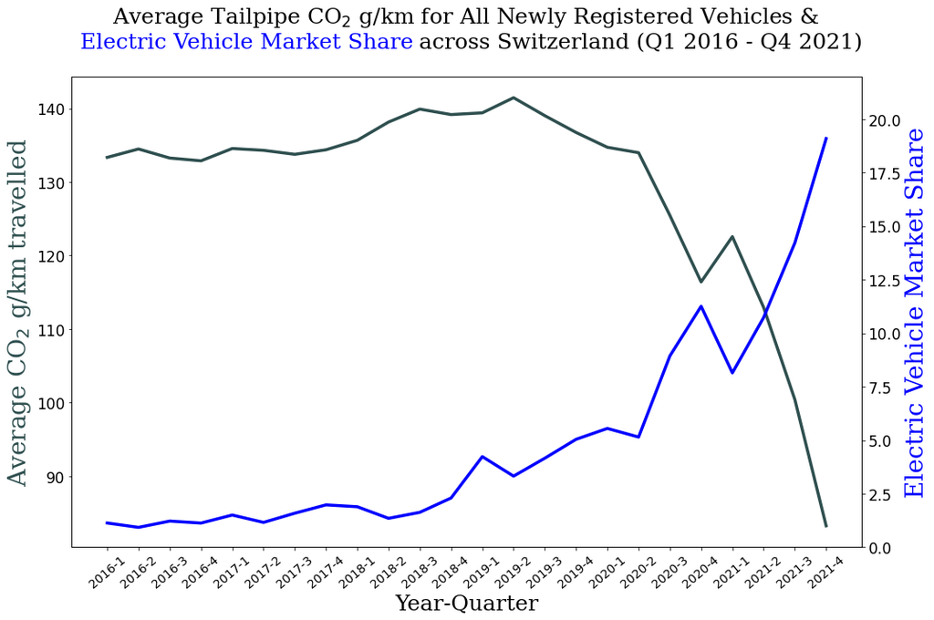

```python
countryLevelGraphs.CO2vsEVMarketShare(CO2Filtered)
```

## Total Number of EVs, Non EVs, EVs

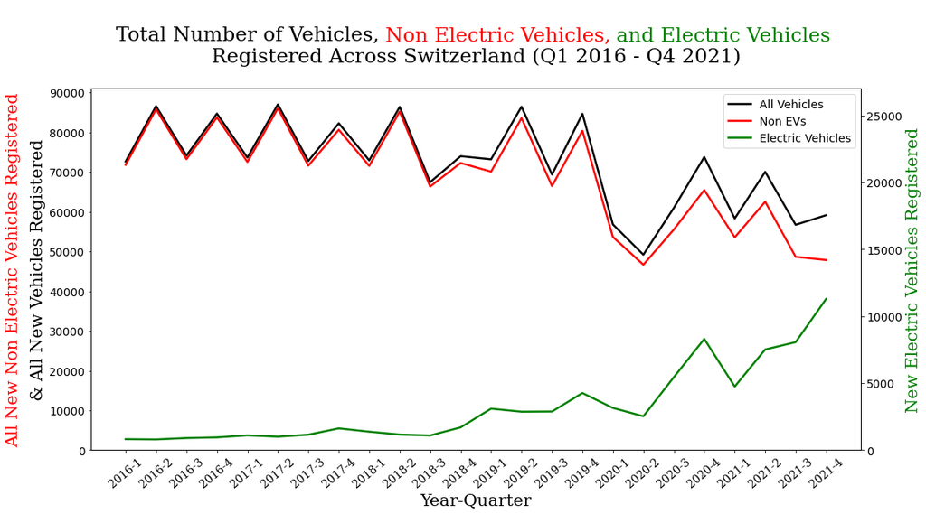

```python
countryLevelGraphs.EVsNonEVsAllVehicles()
```

## Plotting Electric Vehicle Market Share by Canton over Time

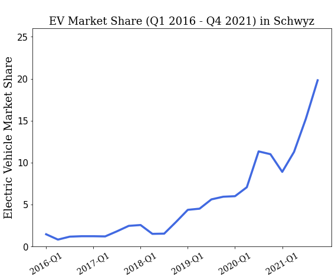

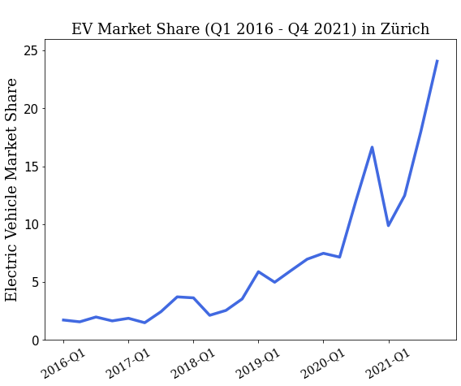

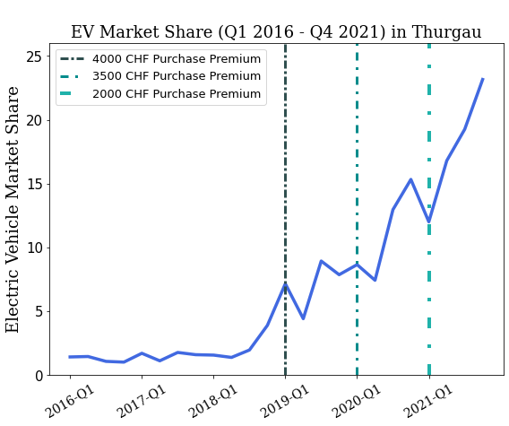

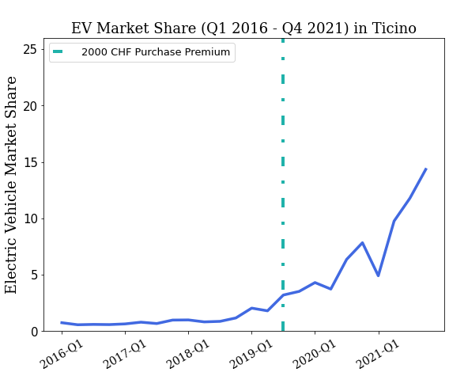

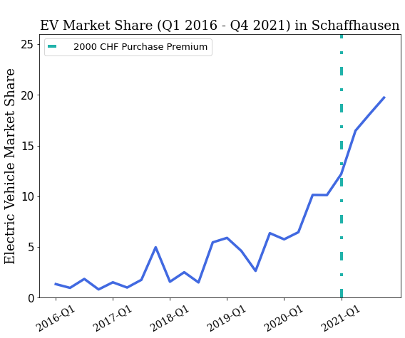

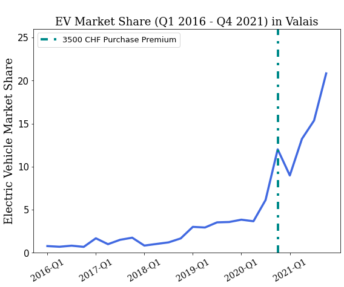

```python
for c in ['SZ','ZH','TG','TI', 'SH', 'VS']:
    cantonLevelGraphs.plotEVRatio(c)
```

## Plotting by number of EV sales

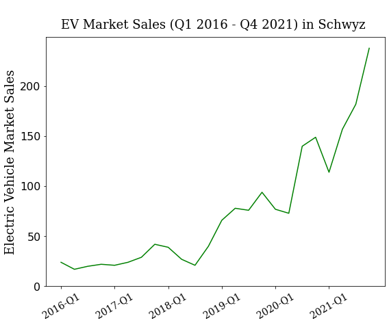

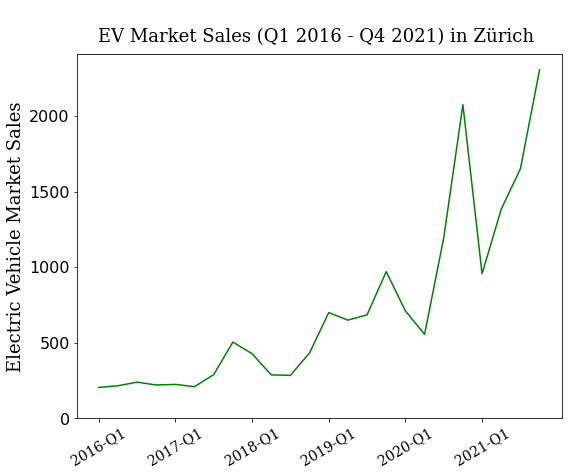

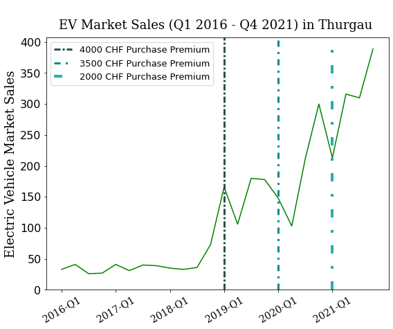

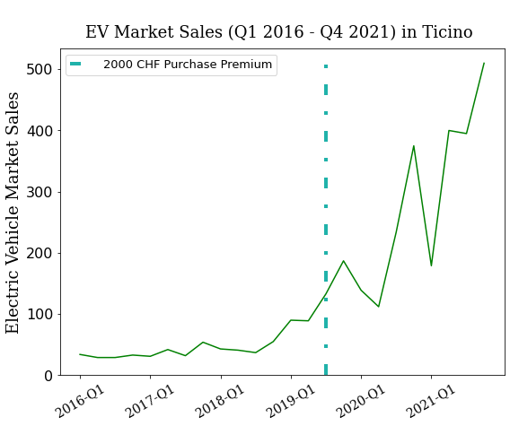

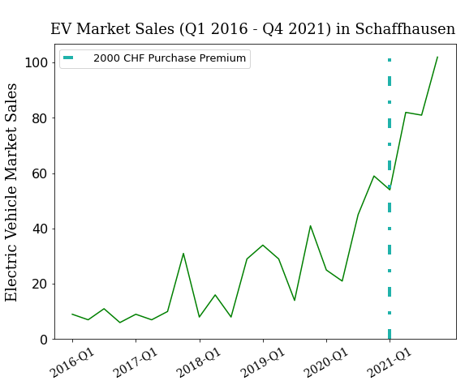

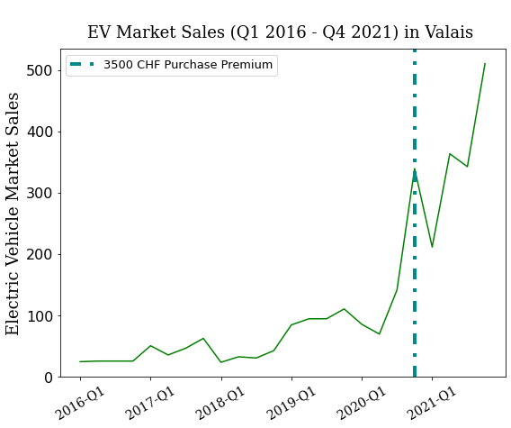

```python
for c in ['SZ','ZH','TG','TI', 'SH', 'VS']:
    cantonLevelGraphs.plotEVs(c)
```

## Plotting by total number of vehicle sales

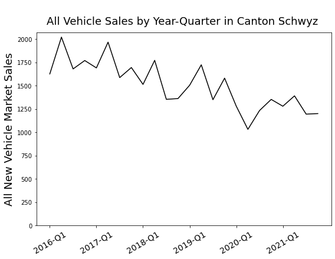

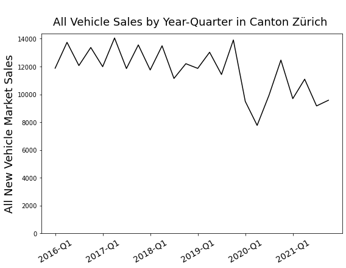

```python
for c in ['SZ','ZH']:
    cantonLevelGraphs.allVehicles(c)
```

## Plotting the residuals at the canton level for a particular control-group model

### This residual analysis allows for better visualization of regression output meanings

```python
### creates graph for analysis based on a given canton abbreviation input ###
def stage12346(c_abbr, Y = 'MkShr(100)_log'):
    residGraph.graph("","",                                                                                                      c_abbr, Y, 0, True )
    residGraph.graph( createModel(model1Regressors[1:], Y),  "(controlled by a constant)",                                       c_abbr, Y, 1, False)
    residGraph.graph( createModel(model2Regressors[1:], Y),  "(controlled by a constant, vehicle price)",                        c_abbr, Y, 2, False)
    residGraph.graph( createModel(model3Regressors[1:], Y),  "(controlled by a constant, vehicle price, social)",                c_abbr, Y, 3, False)
    residGraph.graph( createModel(model4Regressors[1:], Y),  "(controlled by a constant, vehicle price, social, canton)",        c_abbr, Y, 4, False)
    residGraph.graph( createModel(model6Regressors[1:], Y),  "(controlled by a constant, vehicle price, social, canton, quarter)",  c_abbr, Y, 6, False)

    ## Thurgau graph well explains variation post-policy implimentation, however Schauffhausen explains this variation less so
    ## These can be seen when comparing the full model .61 without purchase premium and .62 with purchase premium control.
    if c_abbr in ['TG', 'SH']:
        residGraph.graph(createModel(model6Regressors[1:], Y),"(controlled by a constant, vehicle price, social, canton, quarter)", c_abbr, Y, 61, True)
        residGraph.graph(createModel(model6Regressors, Y),    "(controlled by all controls and the purchase premiums policies)", c_abbr, Y, 62, True)
```

```python
### builds photos into a gif ###
def makeGifs(cantonName):
    images = []
    for i in [1,2,3,4,6,6,6]:
        images.append(imageio.imread("2) Gifs/" + cantonName + '/img' + cantonName + str(i) + '.png'))
    exportname = cantonName +'.gif'
    imageio.mimsave("2) Gifs/" + cantonName + '/' + exportname, images, duration = 1.9)

### stages and creates the gif ###
def stageAndGifs(cantonName):
    stage12346(cantonName)
    makeGifs(cantonName)

for cantonName in ['TG', 'SH', 'VS', 'TI']:
    stageAndGifs(cantonName)
```

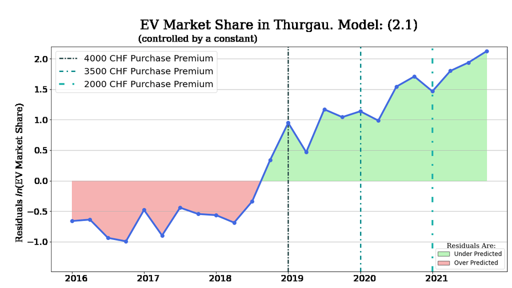

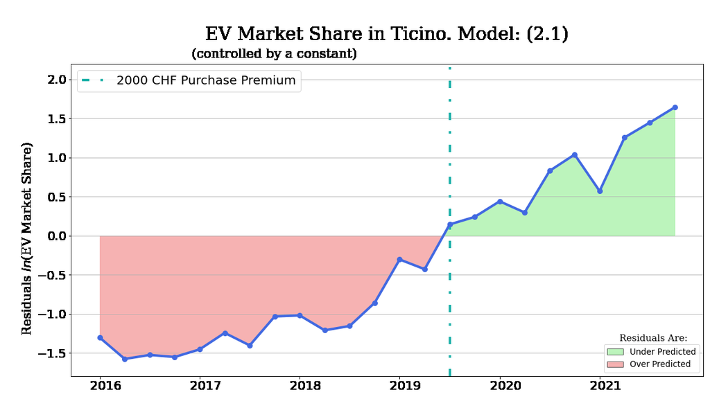

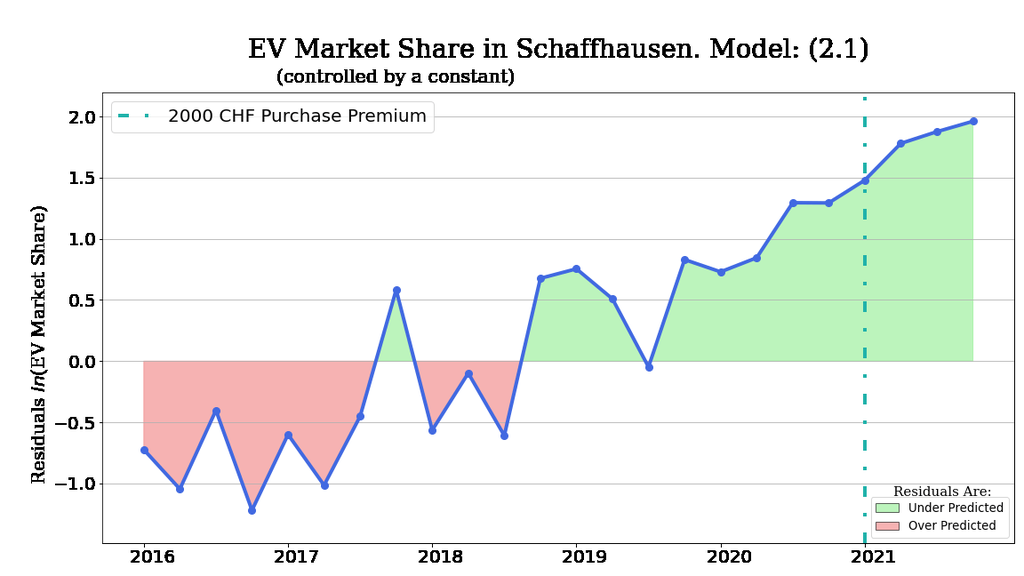

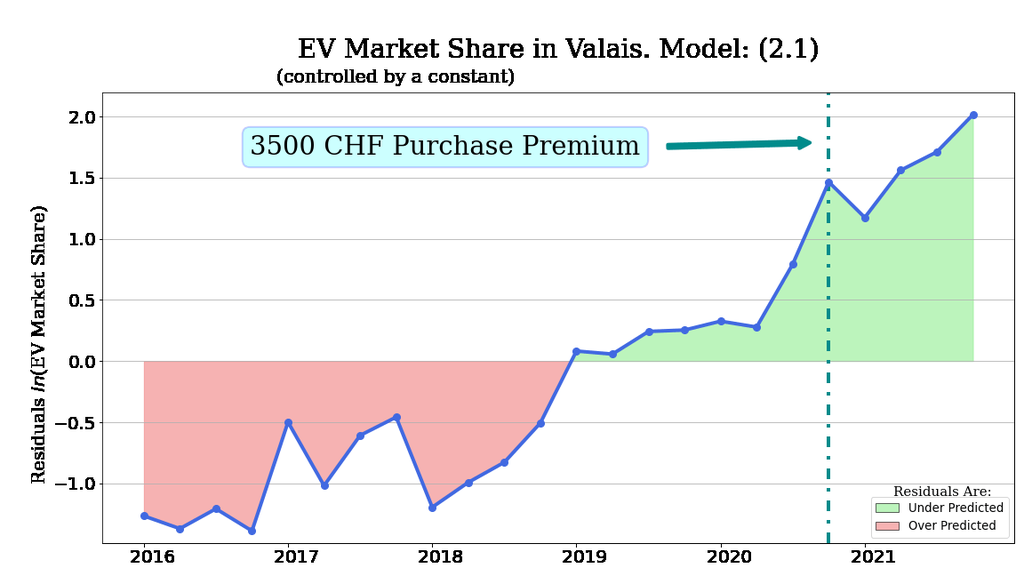

```python
# Display some of the gifs
def displayGif(abbr):
    display(Image(data=open('2) Gifs/' + abbr + '/' + abbr + '.gif','rb').read(), format='png'))
for abbr in [ 'TG', 'TI', 'SH', 'VS']:
    displayGif(abbr)
```

```
Unexplained residuals indicate positive effect of purchase premium policy in canton of Valais,
shown by green region within the red circle in image below
```

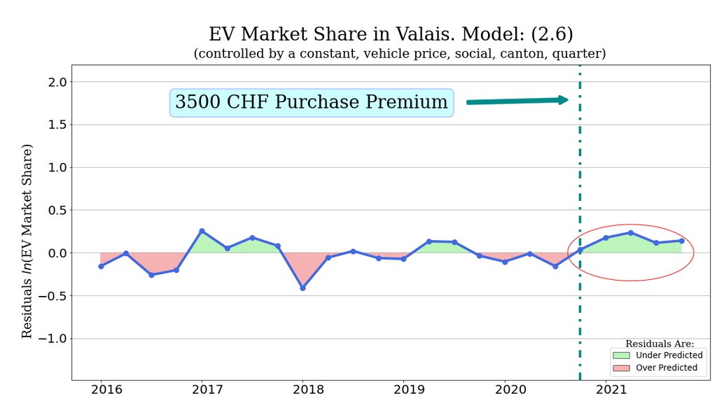

```python
print("Unexplained residuals indicate positive effect of purchase premium policy in canton of Valais, \nshown by green region within the red circle in image below")
Image(filename="2) Gifs/VS/imgVS6.png")
```

```
Flattening of residuals post-policy implimentation indicates well-explained residuals and a positive effect of purchase premium policy in canton of Thurgau
```

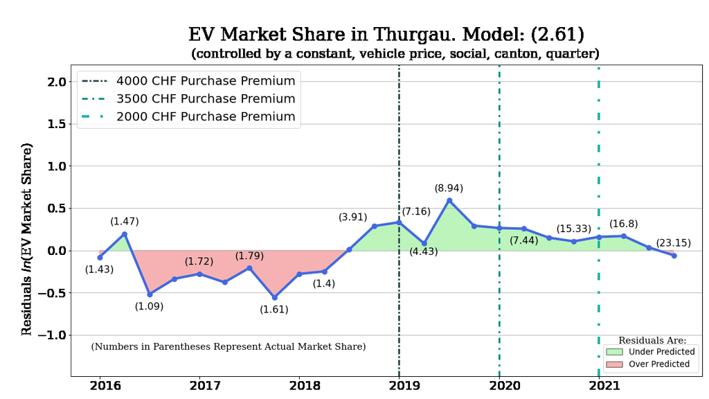

```python
### builds photos into a gif ###
def prePostResiduals(cantonNames):
    for cantonName in cantonNames:
        images = []
        for i in [61,62]:
            images.append(imageio.imread("2) Gifs/" + cantonName + '/img' + cantonName + str(i) + '.png'))
        imageio.mimsave("2) Gifs/" + cantonName + '/' + cantonName +'ResidualChange_PrePost.gif', images, duration = 1.2)

prePostResiduals(['TG'])
print("Flattening of residuals post-policy implimentation indicates well-explained residuals and a positive effect of purchase premium policy in canton of Thurgau")

for abbr in ['TG']:
    display(Image(data=open('2) Gifs/' + abbr + '/' + abbr + 'ResidualChange_PrePost.gif','rb').read(), format='png'))
```

Thank you for your time.

-Lucas